# Git: History, Conflicts, and Ignores

L5: what to do when git says “no”

DSCI 521

## How well do you know the basic workflow by now?

- A. not at all
- B. very superficially
- C. kinda?
- D. kinda well
- E. I eat workflows with my cereal

## Situation: you edited README.md. Your move?

```
$ git status
On branch main
Your branch is up to date with 'origin/main'.

Changes not staged for commit:
  (use "git add <file>..." to update what will be committed)
  (use "git restore <file>..." to discard changes in working directory)
        modified:   README.md

no changes added to commit (use "git add" and/or "git commit -a")
```

--- shuffle_answers: true --- ## The change should end up in the next commit. Which command comes first? 1. [x] `git add README.md` > git add copies the change from the working directory into the staging area. The commit comes after. 1. [ ] `git commit -m "Clarify README"` > Nothing is staged yet, so there is nothing for this commit to record. Git answers: no changes added to commit. `git commit -a` stages every tracked file at once, so you lose the choice of what goes in. 1. [ ] `git push origin main` > Push sends commits to the remote. You have not made one yet. 1. [ ] `git diff` > Useful before adding: diff shows the change and stages nothing.

## Situation: two files changed. Why two sections?

```
$ git status
On branch main
Your branch is up to date with 'origin/main'.

Changes not staged for commit:
  (use "git add <file>..." to update what will be committed)
  (use "git restore <file>..." to discard changes in working directory)
        modified:   README.md

Untracked files:
  (use "git add <file>..." to include in what will be committed)
        analysis.qmd

no changes added to commit (use "git add" and/or "git commit -a")
```

--- shuffle_answers: true --- ## Both files just changed on disk. Why does git list them in two sections? 1. [x] README.md was previously committed, analysis.qmd wasn't > Tracked vs untracked. Modified means "differs from the last commit". Untracked means "no last commit exists for this file". 1. [ ] analysis.qmd is listed in .gitignore > Ignored files do not appear in git status at all. Untracked is the opposite: git shows it and offers to start tracking. 1. [ ] README.md is already staged and ready to commit, analysis.qmd is not > Staged would read "Changes to be committed". The header you saw says the opposite. 1. [ ] Git sorts the sections by file type, .md before .qmd > Git does not care about extensions. The sections are about tracking state.

## Situation: about to add everything at once

```
$ git status
On branch main
Changes not staged for commit:
  (use "git add <file>..." to update what will be committed)
  (use "git restore <file>..." to discard changes in working directory)
        modified:   README.md

Untracked files:
  (use "git add <file>..." to include in what will be committed)
        .ipynb_checkpoints/
        analysis.qmd

no changes added to commit (use "git add" and/or "git commit -a")

$ git add . -vn
add 'README.md'
add '.ipynb_checkpoints/analysis-checkpoint.qmd'
add 'analysis.qmd'
```

--- shuffle_answers: true --- ## Before staging, you ran `git add . -vn`. What does the output tell you? 1. [x] `git add .` would also stage the checkpoint folder > `-n` is the dry-run flag (`--dry-run`): it stages nothing. `-v` lists what it would have staged, so you see the list before anything moves. To ignore checkpoint files add them to `.gitignore`. 1. [ ] The three files are staged and ready to commit > `-n` is the dry-run flag. Nothing moved, and `git status` says exactly what it said before. 1. [ ] Only `README.md` would be staged, since the others are untracked > `git add .` stages untracked files too. That is the risk the dry run is showing you. 1. [ ] The checkpoint folder is ignored, so `git add .` is safe > An ignored file never appears in this listing. It appeared, so no rule ignores it yet.

## Situation: the edit is staged. Your move?

```
$ git status
On branch main
Your branch is up to date with 'origin/main'.

Changes to be committed:
  (use "git restore --staged <file>..." to unstage)
        modified:   README.md
```

--- shuffle_answers: true --- ## Record the staged change in history. Which command? 1. [x] `git commit -m "Clarify README"` > From staging into the repository: the change is now recorded in history. 1. [ ] `git add README.md` > Already staged. Adding again changes nothing. 1. [ ] `git push origin main` > Push sends existing commits. This one does not exist until you commit. 1. [ ] `git log` > git log shows history and records nothing.

## Situation: Commit executed. Where does it exist?

```
$ git commit -m "Clarify README"
[main e695129] Clarify README
 1 file changed, 2 insertions(+), 1 deletion(-)

$ git status
On branch main
Your branch is ahead of 'origin/main' by 1 commit.
  (use "git push" to publish your local commits)

nothing to commit, working tree clean
```

--- shuffle_answers: true --- ## After that commit, where does your work exist? 1. [x] In the repository on your laptop, nowhere else > "Ahead by 1" means exactly this: the remote does not have it. The hint even names the fix. 1. [ ] On your laptop and on GitHub > Then the status would say "up to date". Ahead means the remote is missing your commit. 1. [ ] On GitHub and on every collaborator's laptop > Two steps away: you have not pushed, and they would still need to pull. 1. [ ] In the staging area > The commit moved the snapshot out of staging into the repository. Staging now matches the repo.

## Which copies of the repository have the change?

--- shuffle_answers: true --- ## Which copies of the repository have the change? Some answers apply to more than one situation. - You edit `README.md` with the web pencil and press the green commit button :: Only the remote > The green button commits inside GitHub's copy. Your clone gets it when you pull. - Your teammate pushed an hour ago and you have not pulled :: Only the remote > GitHub does not push to you. Until you pull, your clone does not have it. - A commit you pushed yesterday :: Your clone and the remote > Push copied it up. Since then both repositories have it. - A commit your teammate pushed, and you have already pulled :: Your clone and the remote > Pull brought it down. Your clone and GitHub now match again. - :: Every classmate's clone > Nothing reaches a classmate's clone until that classmate pulls. > A copy has the change only after a commit, push or pull moved it there.

## SSH setup: which piece goes where?

--- shuffle_answers: true --- ## SSH setup: which piece goes where? - The text you paste at github.ubc.ca → Settings → SSH keys :: Public key > The public key is the padlock: safe to hand out, useless for breaking in. - The file that must never leave your laptop :: Private key > Whoever holds it can push as you. It is never pasted or sent anywhere. - What proves it is you when `git push` runs :: Private key > Your machine proves it holds the private key without ever sending it. - What you would also add to github.com so a second site recognizes you :: Public key > The same public key can be added to any number of sites. - :: CWL password > SSH replaces password logins. No step of the setup asks any site for your CWL password. > The public key is shared. The private key never leaves your laptop.

# History

## Situation: what is the story of this repo so far?

```
$ git log
commit e695129184ff5af8c29db8c9cd5660498026a4e4
Author: Ilya Musabirov <ilm@cs.ubc.ca>
Date:   Sun Sep 13 21:23:04 2026 -0700

    Clarify README
...

$ git log --oneline
e695129 Clarify README
c1918c1 Add a description
1e72c14 Initial commit
```

**Solution:** `git log` prints author, date and message for every commit.

- `git log --oneline` prints one line each, for scanning
- `q` quits the pager

The commits page on GitHub shows the same list for the remote.

## Situation: fine, but what exactly changed in that commit?

```
$ git log -p
commit e695129184ff5af8c29db8c9cd5660498026a4e4
Author: Ilya Musabirov <ilm@cs.ubc.ca>
Date:   Sun Sep 13 21:23:04 2026 -0700

    Clarify README

diff --git a/README.md b/README.md
index ea5b31d..0f73c7d 100644
--- a/README.md
+++ b/README.md
@@ -1,3 +1,4 @@
 # 521-git-demo

-A repo for the L5 demo.
+A repo for the L5 lecture demo.
+Clone it, break it, fix it.
```

**Solution:** `git log -p` adds each commit’s patch: `-` lines were removed, `+` lines added.

- `git log -p -1` shows the newest commit alone
- `git show c1918c1` shows the one commit you name
- `q` quits the pager, as in git log

On GitHub, clicking a pushed commit shows the same patch in colour.

## I was away. GitHub shows a commit my log does not. What happened?

- On my laptop
- On github.ubc.ca

```
$ git log --oneline
e695129 Clarify README
c1918c1 Add a description
1e72c14 Initial commit
```

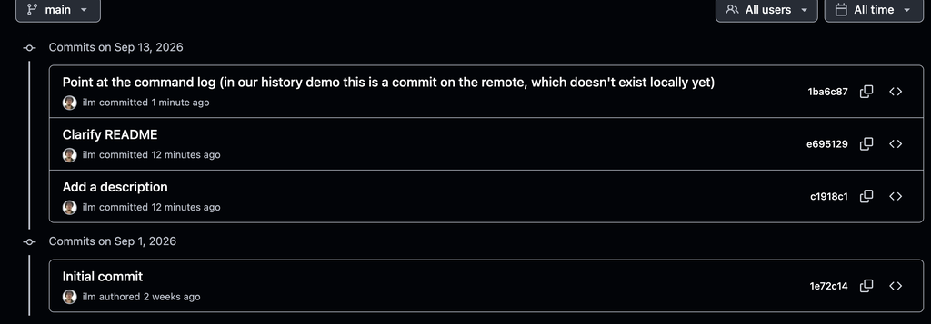

## Situation: I want to compare the changes in more detail

```
$ git status
On branch main
Changes to be committed:
  (use "git restore --staged <file>..." to unstage)
        modified:   README.md

Changes not staged for commit:
  (use "git add <file>..." to update what will be committed)
  (use "git restore <file>..." to discard changes in working directory)
        modified:   analysis.qmd
```

```
$ git diff
diff --git a/analysis.qmd b/analysis.qmd
index 8b151a2..f4413f7 100644
--- a/analysis.qmd
+++ b/analysis.qmd
@@ -1 +1,3 @@
 library(tidyverse)
+
+tea <- read_csv("tea.csv")
```

**Solution:** `git diff` shows the changes that are not staged.

- `git diff --staged` shows the staged ones, the changes your commit will contain
- `git diff <older_sha> <newer_sha>` compares two commits, oldest first
- `git diff <sha>` compares that commit with your files right now

Each `git status` heading has its own diff. “Changes to be committed” is `--staged`. “Changes not staged for commit” is plain `git diff`.

## Situation: git diff on a notebook gives JSON soup

```
$ git diff analysis.ipynb
@@ -15,11 +15,11 @@
   {
    "cell_type": "code",
    "id": "e5f6a7b8",
-   "execution_count": 2,
+   "execution_count": 3,
    "metadata": {},
    "outputs": [],
    "source": [
-    "df.groupby(\"month\").size()"
+    "df.groupby(\"month\")[\"mm\"].mean()"
    ]
   }
  ],
```

```bash
uv tool install nbdime
nbdime config-git --enable --global
```

Now the same command reads cells:

```
$ git diff analysis.ipynb
## replaced /cells/1/execution_count:
-  2
+  3

## modified /cells/1/source:
-  df.groupby("month").size()
+  df.groupby("month")["mm"].mean()
```

`nbdiff-web` opens it in a browser. VS Code and Positron also render notebook diffs cell by cell in their Source Control panes.

# Fixing small problems (without creating new)

## Situation: I staged a file I did not mean to commit

```
$ git status
On branch main
Changes to be committed:
  (use "git restore --staged <file>..." to unstage)
        modified:   README.md
        modified:   notes.txt
```

**Solution:** `git restore --staged notes.txt`

The change is still in your working directory, but not in staging area anymore.

## Situation: I ruined a file with my edits and want the last committed version back

```
$ git restore analysis.qmd
$ git status
On branch main
nothing to commit, working tree clean
```

**Solution:** `git restore <file>` replaces your working copy from the last commit. It prints nothing; `git status` is how you check.

- `git restore --source <sha> <file>` takes it from a named commit

**Warning:** your uncommitted edits to that file are gone **for good**.

## Situation: I deleted something from a file three commits ago

```
$ git log --oneline
a096de6 Fix a typo in the README
100bf34 Add install notes
34dba92 Accidentally delete dependencies
4c22f68 Add dependency list

$ git restore --source 4c22f68 README.md
```

```
$ git status
On branch main
Changes not staged for commit:
  (use "git add <file>..." to update what will be committed)
  (use "git restore <file>..." to discard changes in working directory)
        modified:   README.md

$ git add README.md
$ git commit -m "Restore dependency list"
```

**Solution:** `--source` names the commit to take the file from.

Find the commit BEFORE the deletion and use its sha.

The restore prints nothing, so check with `git status`: it now calls `README.md` modified, because the version you pulled back differs from the current commit. Nothing is rewritten. Add and commit it like any edit, and the fix lands as a new commit on top.

# Undoing whole commits

## Situation: the commit is a mistake, and it is already on GitHub

```
$ git log --oneline
0aeeb49 Accidentally delete dependencies
d62ce00 Add dependency list

$ git revert 0aeeb49
[main 4a75ac0] Revert "Accidentally delete dependencies"
 1 file changed, 5 insertions(+)

$ git log --oneline
4a75ac0 Revert "Accidentally delete dependencies"
0aeeb49 Accidentally delete dependencies
d62ce00 Add dependency list
```

**Solution:** `git revert <sha>` makes a new commit that undoes the old one.

The sha names the commit you want to **cancel**, not one to go back to.

An editor opens with the message already written for you:

```
COMMIT_EDITMSG
```

```
Revert "Accidentally delete dependencies"

This reverts commit 0aeeb49d2a81...
```

Save and quit, and the history keeps both: the mistake and the fix. That is what makes it safe to share.

## What are the advantages and disadvantages of how revert works?

```
$ git log --oneline
0aeeb49 Accidentally delete dependencies
d62ce00 Add dependency list

$ git revert 0aeeb49
[main 4a75ac0] Revert "Accidentally delete dependencies"
 1 file changed, 5 insertions(+)

$ git log --oneline
4a75ac0 Revert "Accidentally delete dependencies"
0aeeb49 Accidentally delete dependencies
d62ce00 Add dependency list
```

## Situation: the commit is a mistake, and nobody has seen it or should

```
$ git reset HEAD~1
Unstaged changes after reset:
M   README.md

$ git status
On branch main
Changes not staged for commit:
  (use "git add <file>..." to update what will be committed)
  (use "git restore <file>..." to discard changes in working directory)
        modified:   README.md

no changes added to commit (use "git add" and/or "git commit -a")
```

**Solution:** `git reset <sha>` sets main to point at `<sha>`. It leaves your working directory unchanged, so you still have all the changes from those commits in your files, ready to fix and commit again.

`HEAD~1` is one commit before the current one, so this resets to the commit before the mistake.

The sha is the commit to reset **to**, not the one you cancel.

Only while unpushed: a secret already on GitHub must be rotated.

## Same reset, two flags: `--soft` and `--hard`

```
$ git reset --soft HEAD~1

$ git status
On branch main
Changes to be committed:
        modified:   README.md
```

```
$ git reset --hard HEAD~1
HEAD is now at 5021352 Add dependency list

$ git status
On branch main
nothing to commit, working tree clean
```

**Solution:** same command, same commits removed from main. The flag decides how much else git changes.

- `--soft`: nothing else, so the changes show as staged
- no flag: only resets the staging area, so the changes show as unstaged
- `--hard`: your working directory gets overwritten from commit `<sha>` too, so your work is gone

Use `--soft` for a wrong message or a forgotten file.

Only while unpushed: a secret already on GitHub must be rotated.

## Situation: I reset, and now push is refused

```
$ git push origin main
To github.ubc.ca:mds-2026-27/DSCI_521_git_demo_yourcwl.git
 ! [rejected]        main -> main (non-fast-forward)
error: failed to push some refs
hint: Updates were rejected because the tip of your
hint: current branch is behind its remote counterpart.
hint: Integrate the remote changes (e.g. 'git pull ...')
hint: before pushing again.
```

```
$ git push --force-with-lease origin main
To github.ubc.ca:mds-2026-27/DSCI_521_git_demo_yourcwl.git
 + 896823d...7adaaae main -> main (forced update)
```

**Solution:** push the rewritten history, with a safety check.

- `--force-with-lease` refuses if the remote updated since your last pull/fetch, so you will make an informed decision
- `--force` overwrites no matter what

Always prefer `--force-with-lease`, not `--force`, as one last safety check before pushing irreversible changes.

On a shared repo: talk to the team first, or revert instead of rewriting.

## Which command fits?

--- shuffle_answers: true --- ## You made a mistake in your last commit and want its changes gone permanently. No collaborators. The commit should vanish from history. What do you run? 1. [x] `git reset --hard ` > Branch moves back and the changes are discarded. That is the full-erase case. 1. [ ] `git reset ` > Moves main back and leaves your files alone, so the mistake would still be sitting there, uncommitted. 1. [ ] `git revert ` > Undoes the changes but keeps both commits in history. You wanted it gone from history. 1. [ ] `git restore ` > Only touches working-directory edits to one file. Cannot remove a commit.

## Which command fits?

--- shuffle_answers: true --- ## Same mistake, no collaborators, but you want the commit gone and its changes back in your working files, ready to fix and recommit. What do you run? 1. [x] `git reset ` > Main moves back and your files are left alone, so the changes are uncommitted again. Fix, add, commit again. 1. [ ] `git reset --hard ` > This erases the changes too. You wanted to keep the work. 1. [ ] `git revert ` > Leaves the bad commit in history. You wanted it removed before recommitting. 1. [ ] `git push --force-with-lease` > Pushes rewritten history. You have not rewritten anything yet.

## Which command fits?

--- shuffle_answers: true --- ## You made a mistake in your last commit. You have collaborators and want the fix visible in history and safe for everyone. What do you run? 1. [x] `git revert ` > A new commit undoes the old one. Everyone pulls it like any other commit. 1. [ ] `git reset --hard ` > Rewrites shared history. Your collaborators' repos now disagree with the remote. 1. [ ] `git push --force-with-lease` > Even with the lease, you are rewriting history your collaborators already have. 1. [ ] `git restore ` > Working-directory only. The mistake is already committed.

# Interruptions

## I am mid-edits, but I need to pull latest changes right now

```
$ git pull origin main
error: Your local changes to the following files
would be overwritten by merge:
    README.md
Please commit your changes or stash them before you merge.
Aborting
```

**Solution:** put the half-done work in git’s pocket, pull, take it back.

```
$ git stash
Saved working directory and index state
WIP on main: 915297f Add README

$ git pull origin main
Updating 915297f..088c9dd
Fast-forward
 README.md | 2 ++

$ git stash pop
Auto-merging README.md
        modified:   README.md
Dropped refs/stash@{0}
```

## Which command fits?

--- shuffle_answers: true --- ## You have half-done changes you are not ready to commit. git pull refuses because of them, and you need the remote update now. Best next command? 1. [x] `git stash` > Saves the changes aside and leaves a clean working directory, so the pull proceeds. Pop them back after. 1. [ ] `git commit -m "WIP"` > Works, but now a half-done "WIP" commit is in your history for the TA to enjoy. 1. [ ] `git reset --hard` > Deletes your uncommitted work entirely. Nothing to bring back afterwards. 1. [ ] `git fetch origin` > Fetch brings the new commits into your repository, but your working files and the refused merge are exactly where they were.

# Merges

## When are you most likely to get a merge conflict?

--- shuffle_answers: true --- ## When are you most likely to get a merge conflict? 1. [ ] You and a collaborator change different files. > Git merges these without asking. Different sheets of the house entirely. 1. [ ] You and a collaborator change different lines in the same file. > Still an automatic merge: the regions do not overlap. 1. [x] You and a collaborator change the exact same line(s) in the same file. > Two claims on the same region. Git stops and asks you to choose. 1. [ ] You forget to git commit before you git push. > Push sends the commits that exist. No merge is involved yet.

## Situation: pull refuses and lectures me about divergent branches

```
$ git pull origin main
hint: You have divergent branches and need to specify
hint: how to reconcile them.
hint:
hint:   git config pull.rebase false  # merge
hint:   git config pull.rebase true   # rebase
hint:   git config pull.ff only       # fast-forward only
fatal: Need to specify how to reconcile divergent branches.
```

**Solution:** the three hints are three strategies. We merge.

- `git pull --no-rebase` means “prefer to merge”, and is what we use

Rebase and fast-forward-only are the other two. You will meet them in 524.

You can also set it once: `git config --global pull.rebase false`

If a pull has stopped on a conflict you do not want to resolve now, `git merge --abort` tries to put the repository back to before the pull. Commit or stash first, or it may not manage.

## Situation: the pull went through, and now the file has arrows in it

```
$ git pull --no-rebase origin main
Auto-merging README.md
CONFLICT (content): Merge conflict in README.md
Automatic merge failed; fix conflicts and then
commit the result.

$ git status
You have unmerged paths.
  (fix conflicts and run "git commit")
  (use "git merge --abort" to abort the merge)

Unmerged paths:
  (use "git add <file>..." to mark resolution)
        both modified:   README.md
```

```
README.md
```

```
<<<<<<< HEAD
Important local change
=======
A very important remote change
>>>>>>> e420e19...
```

**Solution:** edit the file to what it should say, delete all three markers, then `add`, `commit`, `push`.

`HEAD` is yours. Below the `=======` is what came down from the remote.

## Situation: the conflict is inside a notebook

```
$ git pull --no-rebase origin main
Auto-merging analysis.ipynb
CONFLICT (content): Merge conflict in analysis.ipynb
Automatic merge failed; fix conflicts and then
commit the result.
```

```
analysis.ipynb
```

```
   "source": [
<<<<<<< HEAD
    "df.groupby(\"month\")[\"mm\"].median()"
=======
    "df.groupby(\"month\")[\"mm\"].mean()"
>>>>>>> 1f9a99f...
   ]
```

**Solution:** the markers land inside the JSON, so the file no longer opens as a notebook. Resolve it in a text editor: keep the cell you want and delete all three markers, exactly as you would in any file.

- `nbdiff` shows what actually differs, cell by cell
- pull before you start working, and this rarely happens

Small commits and frequent pushes are the real fix.

# Reading the room

## What happens when you pull?

```
$ git status
On branch main
Your branch is up to date with 'origin/main'.

$ git fetch origin
   0179069..695ea18  main       -> origin/main

$ git status
On branch main
Your branch is behind 'origin/main' by 2 commits,
and can be fast-forwarded.
  (use "git pull" to update your local branch)

$ git merge origin/main
```

`git fetch` downloads the remote’s new commits and updates `origin/main`. Your own files do not change.

--- shuffle_answers: true --- ## `git pull` = fetch + merge in this case. What will the merge do here? 1. [x] Update main to origin/main, with nothing to combine > You committed nothing, so the merge has no work of yours to reconcile. Main catches up to where remote main already is. Git's word for that is on your screen: fast-forwarded. 1. [ ] Combine your commits with theirs into a new commit > That is what a merge does when both sides have moved. Here only the remote moved. 1. [ ] Stop and ask you to resolve a conflict > A conflict needs commits on both sides touching the same lines. Only the remote moved here, so there is nothing of yours to disagree with. 1. [ ] Nothing: your copy already matches the remote > That was the first status, answered from your own copy before the fetch. The second status, after the fetch, is the one that knows about the remote.

## Situation: my push was rejected

```
$ git push origin main
To github.ubc.ca:mds-2026-27/DSCI_521_git_demo_yourcwl.git
 ! [rejected]        main -> main (non-fast-forward)
error: failed to push some refs to 'github.ubc.ca:mds-2026-27/DSCI_521_git_demo_yourcwl.git'
hint: Updates were rejected because the tip of your current branch is behind
hint: its remote counterpart. Integrate the remote changes (e.g.
hint: 'git pull ...') before pushing again.
hint: See the 'Note about fast-forwards' in 'git push --help' for details.
```

--- shuffle_answers: true --- ## The push was rejected. What do you do next? 1. [x] `git pull --no-rebase origin main`, then push again > Pull fetches the remote commits and merges them with yours. `--no-rebase` tells git to merge. This time there are changes on both sides, so the merge will ask you what to prefer (as in week 3 lab). 1. [ ] `git push --force-with-lease origin main` > The lease refuses exactly here, because the remote moved. Forcing past it would delete a teammate's commits. 1. [ ] Commit again, then push > The message is not about uncommitted work. Your commits are fine. The remote is ahead of you. 1. [ ] Do nothing: the hint lines mean it went through > The first line says "rejected", so nothing was sent. The hints are instructions, not a receipt.

# Ignores

## Situation: git status is full of files I never want to commit

```
$ git status
On branch main
Untracked files:
  (use "git add <file>..." to include in what will be committed)
        .DS_Store
        .ipynb_checkpoints/

nothing added to commit but untracked files present
```

**Solution:** a `.gitignore` file, committed like any other.

```
.gitignore
```

```
.DS_Store
**/.ipynb_checkpoints/
```

`.gitignore` only covers files git is not already tracking. For a file you already committed: `git rm --cached data.csv`, then commit. That means “stop tracking this”, not “delete this”: the file stays in your working directory *and in the old commits*.

## How confident do we feel about the conflict you are about to create?

- A. Don’t make me cry rn :(
- B. …
- C. Meh
- D. …
- E. Bring it on